# pkern_vignette

Dean Koch 2021-11-09

**Mitacs UYRW project**

**pkern**: Fast kriging on gridded datasets

Standard kriging methods don’t scale well on problems with high resolution and large geographical extent, such as when downscaling weather data. `pkern` gets around this issue using product kernels, which simplify kriging computations to substantially reduce their memory and CPU demands. We use a combination of new methods and ones described in Gilboa et. al (2015), Koch et. al (2021).

This vignette uses `pkern` to interpolate soil data from the “meuse” dataset (included with `gstat`), showing how to use the main functions in the package by way of example in a kriging workflow optimized for computational simplicity:

- `pkern_fromRaster` defines a grid based on an existing raster (optional)
- `pkern_snap` snaps input point data to a regular subgrid
- `pkern_vario` and `pkern_vario_fit` fit a separable spatial covariance model to the data
- `pkern_cmean` computes conditional mean (kriging estimates) on full grid
- `pkern_variance` computes kriging variance (pointwise)

## Getting started

`pkern` requires two additional packages: `Matrix` and `RcppHungarian`. The first helps reduce memory usage, and the second allows snapping of input points to distinct grid points. Make sure these can be loaded before using `pkern`:

```r
# dependencies of the pkern package
library(Matrix)
library(RcppHungarian)
```

Install `pkern` by running:

```r
#install.packages('pkern')
#library(pkern)
```

TEMPORARY: I’m still developing the package so for now the above lines above are commented and I instead load all package functions by sourcing the following R files:

```r
# source code for development version of the pkern package
library(here)
source(here('R/pkern_computation.R'))
source(here('R/pkern_covariance.R'))
source(here('R/pkern_indexing.R'))
source(here('R/pkern_plot.R'))
source(here('R/pkern_raster.R'))
source(here('R/pkern_snap.R'))
source(here('R/pkern_variograms.R'))
```

The `sf` and `raster` packages are also recommended for loading your spatial data (they are used in the examples below), but they are not strictly required by `pkern`.

```r
# some libraries for opening geospatial data
library(raster)
library(sf)
```

Finally, we need the `gstat` package to load the “meuse” dataset

```r
library(gstat)
```

## Example data

We will look at the “meuse” dataset (Pebesma, 2009) on heavy metal concentrations in the Meuse river floodplain in the Netherlands. These data are included with the `gstat` package that we just loaded (see this [tutorial pdf](https://cran.r-project.org/web/packages/gstat/vignettes/gstat.pdf)), so they can now be accessed with the following call:

```r
# load meuse dataframe into variable named `meuse`
data(meuse)
str(meuse)
```

```
## 'data.frame':    155 obs. of  14 variables:
##  $ x      : num  181072 181025 181165 181298 181307 ...
##  $ y      : num  333611 333558 333537 333484 333330 ...
##  $ cadmium: num  11.7 8.6 6.5 2.6 2.8 3 3.2 2.8 2.4 1.6 ...
##  $ copper : num  85 81 68 81 48 61 31 29 37 24 ...
##  $ lead   : num  299 277 199 116 117 137 132 150 133 80 ...
##  $ zinc   : num  1022 1141 640 257 269 ...
##  $ elev   : num  7.91 6.98 7.8 7.66 7.48 ...
##  $ dist   : num  0.00136 0.01222 0.10303 0.19009 0.27709 ...
##  $ om     : num  13.6 14 13 8 8.7 7.8 9.2 9.5 10.6 6.3 ...
##  $ ffreq  : Factor w/ 3 levels "1","2","3": 1 1 1 1 1 1 1 1 1 1 ...
##  $ soil   : Factor w/ 3 levels "1","2","3": 1 1 1 2 2 2 2 1 1 2 ...
##  $ lime   : Factor w/ 2 levels "0","1": 2 2 2 1 1 1 1 1 1 1 ...
##  $ landuse: Factor w/ 15 levels "Aa","Ab","Ag",..: 4 4 4 11 4 11 4 2 2 15 ...
##  $ dist.m : num  50 30 150 270 380 470 240 120 240 420 ...
```

Kriging assumes that a multivariate Gaussian process is generating the data. In our example the input data will be zinc concentrations, which are strictly non-negative and skewed, so we first log-transform and recenter the data to get something closer to a Gaussian random variable.

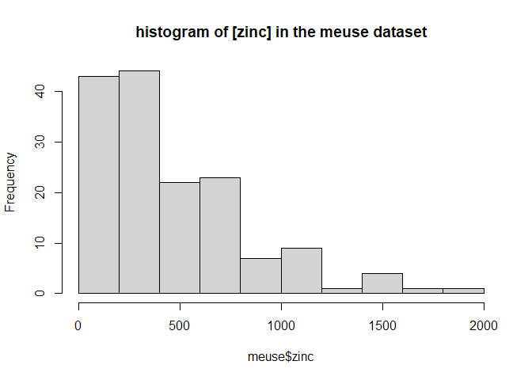

```r
# histogram of the input data
hist(meuse$zinc, main='histogram of [zinc] in the meuse dataset')
```

This chunk does the transformation and appends it to `meuse` in the new column “logzinc”. We save the centering constant in variable `logzinc.mean` so we can invert the transformation later on.

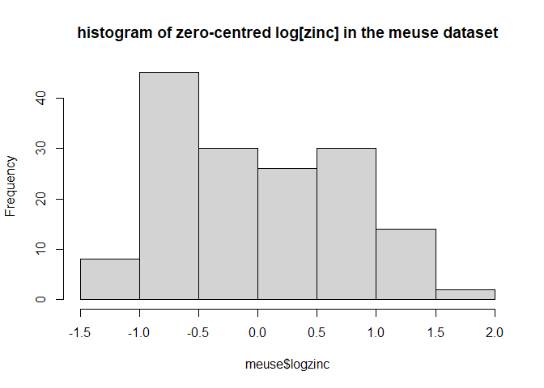

```r
# write new variable logzinc and copy the intercept
logzinc = scale(log(meuse$zinc), center=TRUE, scale=FALSE)
logzinc.mean = attr(logzinc, 'scaled:center')
meuse$logzinc = as.numeric(logzinc)

# histogram of the transformed data
hist(meuse$logzinc, main='histogram of zero-centred log[zinc] in the meuse dataset')
```

The `meuse` dataframe has columns “x” and “y” for the projected Easting and Northing coordinates, so it can be converted to a spatial points object in R. Here’s how this is done with package `sf`

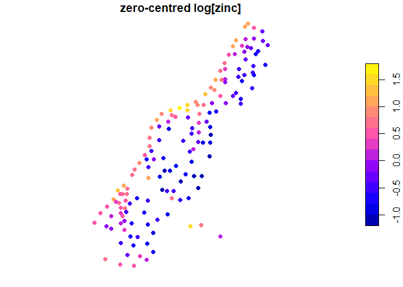

```r
# EPSG coordinate reference system code for meuse data
meuse.epsg = 28992

# convert meuse to an sf points object then plot log[zinc]
meuse.sf = st_as_sf(meuse, coords=c('x', 'y'), crs=meuse.epsg)
plot(meuse.sf['logzinc'], pch=16, main='zero-centred log[zinc]')
```

The river Meuse runs diagonally across this map (from bottom-left to top-right), and points are sampled along its east bank. This vignette will demonstrate how to interpolate the zinc data onto a high resolution grid covering the whole plot window.

## Prediction grid

`pkern` needs a regular grid to predict over - in the examples below we will define one of size 1000 x 1000 (dimensions `gdim`). The grid is positioned to cover the extent of the input soil data coordinates, with coordinates of each grid line (“y” and “x”) calculated and stored in the list `gxy` below:

```r
# define grid size
gdim = c(1e3, 1e3) |> setNames(c('y', 'x'))

# extract input points extent, switching from x-y (order returned by package sf) to y-x order
gext = apply(st_coordinates(meuse.sf), 2, range, simplify=FALSE) |> rev() |> setNames(c('y', 'x'))

# calculate resolution (distance between adjacent grid lines in y and x dimensions)
gres = Map(\(ext, d) diff(ext) / (d-1), ext=gext, d=gdim) |> setNames(c('y', 'x'))

# calculate equally spaced grid line positions
gyx = Map(\(r, g) seq(r[1], r[2], by=diff(r)/g), r=gext, g=gdim-1) |> setNames(c('y', 'x'))
```

We use `setNames` here to clarify the ordering of dimensions - all `pkern` objects store their dimension-wise quantities in the order y, x. For example, the first entry of `gyx` is a vector of y coordinates giving the (vertical) positions of the “y grid lines”.

```r
# print the first few entries of the first vector in gyx (y coordinates)
gyx[[1]] |> head()
```

```
## [1] 329714.0 329717.9 329721.8 329725.7 329729.6 329733.5
```

## Ordering in pkern

Similarly, data values in `gfull` are stored in column-vectorized order, with y coordinates decreasing and x coordinates increasing. This matches base R behaviour for vectorizing matrices (as in `base::c` and `base::as.vector`). However, various other R packages (like `graphics` and `raster`) use different vectorization orderings - if you are needing to convert between them, see `?pkern_r2c`.

The average user shouldn’t have to worry much about this, as most of the important functions in `pkern` support `RasterLayer` and `sf` class arguments, and objects like `gres` and `gyx` are computed internally in the correct order. In particular `pkern_fromRaster` and `pkern_toRaster` can be used to switch to and from `RasterLayer` class, as we demonstrate next.

## Raster data

I expect many users will already have an existing raster file (such as a DEM) that they want to predict onto. These data are often loaded into R using the `raster` package. The following code shows how to get the grid info from above (`gyx` etc) from a `RasterLayer`:

```r
# make an example raster by supplying grid line coordinates (in x-y order!)
gfull.r = raster::rasterFromXYZ(expand.grid(rev(gyx)), crs=meuse.epsg)
# convert RasterLayer to `pkern`-style grid definition list and print structure
gfull = pkern_fromRaster(gfull.r)
str(gfull)
```

```
## List of 5
##  $ gdim: Named num [1:2] 1000 1000
##   ..- attr(*, "names")= chr [1:2] "y" "x"
##  $ gres: Named num [1:2] 3.9 2.79
##   ..- attr(*, "names")= chr [1:2] "y" "x"
##  $ crs : chr "PROJCRS[\"Amersfoort / RD New\",\n    BASEGEOGCRS[\"Amersfoort\",\n        DATUM[\"Amersfoort\",\n            E"| __truncated__
##  $ gyx :List of 2
##   ..$ y: num [1:1000] 329714 329718 329722 329726 329730 ...
##   ..$ x: num [1:1000] 178605 178608 178611 178613 178616 ...
##  $ gval: logi [1:1000000] NA NA NA NA NA NA ...
```

```r
# convert back to RasterLayer
pkern_toRaster(gfull)
```

```
## Warning in showSRID(SRS_string, format = "PROJ", multiline = "NO", prefer_proj = prefer_proj): Discarded datum Amersfoort in Proj4
## definition

## class      : RasterLayer
## dimensions : 1000, 1000, 1e+06  (nrow, ncol, ncell)
## resolution : 2.787788, 3.900901  (x, y)
## extent     : 178603.6, 181391.4, 329712, 333613  (xmin, xmax, ymin, ymax)
## crs        : +proj=sterea +lat_0=52.1561605555556 +lon_0=5.38763888888889 +k=0.9999079 +x_0=155000 +y_0=463000 +ellps=bessel +units=m +no_defs
## source     : memory
## names      : layer
## values     : NA, NA  (min, max)
```

## PROJ4 warnings

You’ll notice the calls above issued a warning about datum strings. This is related to R’s [PROJ6/GDAL3 migration](https://cran.r-project.org/web/packages/rgdal/vignettes/PROJ6_GDAL3.html) which deprecates the old PROJ4 strings in favour of modern well-known-text (WKT) and EPSG codes, creating some dependency issues that are not completely resolved yet.

In this case, coordinate reference metadata is handled in `pkern_fromRaster(r)` by copying the WKT string from `raster::wkt(r)` to the list element “crs”. `pkern_toRaster` then passes this string to `raster:raster`, which appears to convert it to PROJ4 at some point. As PROJ4 is being phased out, I imagine this will be changed soon in updates to `raster` and `sp`, and the warning should disappear.

## Snapping inputs to subgrid

A key requirement of `pkern` is that sampled points lie on a regular subgrid of the full prediction grid (`gfull`), where smaller subgrids (ie fewer grid lines) are to be preferred for computational efficiency. This means users should seek the smallest possible regular subgrid while limiting positional errors to an acceptable level.

`pkern_snap` finds this subgrid and snaps points to it. Argument `sep=c(y, x)` specifies the subgrid spacing, in terms of the factor(s) by which to multiply the outer grid resolution to get the subgrid resolution. For example, minimal spacing is `sep=c(1,1)`, which specifies to make the subgrid equal to the full grid.

In other words we simply snap to the nearest grid point, as in the following:

```r
# snap zinc data to nearest grid point (`sep=1` is short for `sep=c(1,1)`)
gsnap.nearest = pkern_snap(gfull, pts=meuse.sf, sep=1, distinct=FALSE)

# print the range of snapping distances
gsnap.nearest$sg$pdist |> range()
```

```
## [1] 0.08108108 2.36793023
```

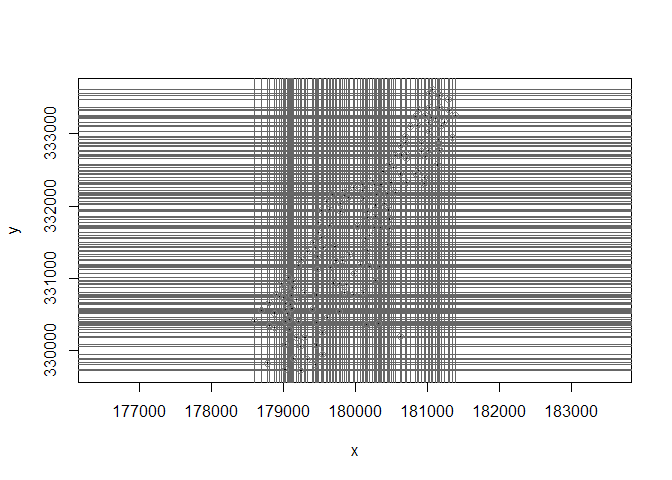

```r
# plot snapping pattern using helper function
pkern_snap_plot(gsnap.nearest, meuse.sf)
```

This minimizes total positional error (the largest snapping distance is about 2m) but results in the most complicated subgrid possible (the full grid itself). This will lead to sluggish computations and high memory demands.

We can simplify by considering sparser subgrids: For example, the code below sets `sep=c(10,10)`, forcing the snapping function to select a subgrid in which the spacing between adjacent subgrid lines is equal to 10x the spacing in the outer grid - ie only every 10th grid line is used.

```r
# snap zinc data to nearest subgrid point (10X coarser than full grid)
gsnap.nearest.10 = pkern_snap(gfull, pts=meuse.sf, sep=10, distinct=FALSE)

# print the sep values - the dimensions of the subgrid
print(gsnap.nearest.10$sg$gdim)
```

```
##   y   x
## 100 100
```

```r
# and print snapping distance range
gsnap.nearest.10$sg$pdist |> range()
```

```
## [1]  0.2593037 31.2480224
```

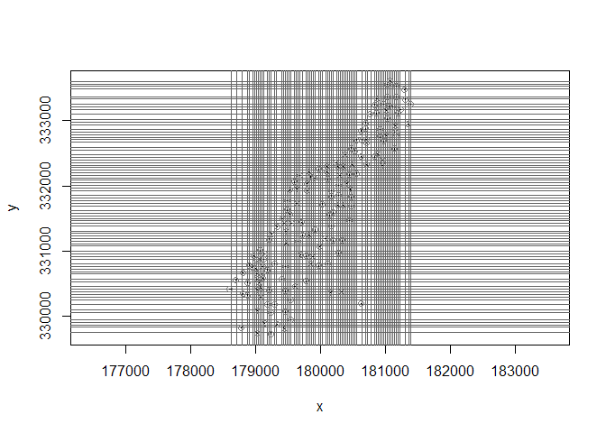

```r
# plot snapping distance
pkern_snap_plot(gsnap.nearest.10, meuse.sf)
```

With wider spacing the positional error has increased - the largest snapping distance is now around 30m - but the subgrid is now substantially simpler (only 100 grid lines are used along each dimension instead of 1000). When `sep` is not supplied, `pkern_snap` will suggest a value automatically (see `?pkern_estimate_sep`).

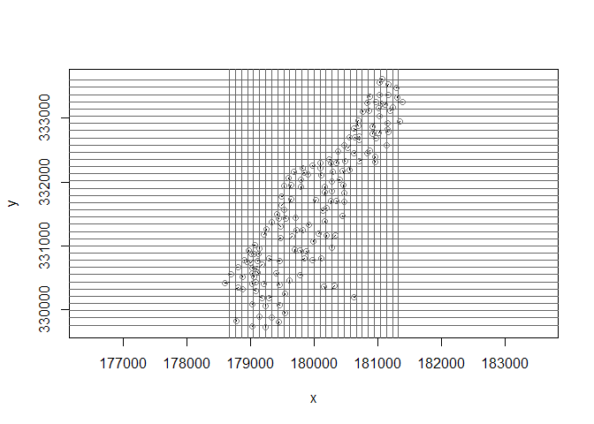

```r
# snap with sep auto-detected, plot, and print snapping info
gsnap.nearest.auto = pkern_snap(gfull, pts=meuse.sf, distinct=FALSE)
pkern_snap_plot(gsnap.nearest.auto, meuse.sf)
```

```r
gsnap.nearest.auto$sg$pdist |> range()
```

```
## [1]  1.551521 71.696645
```

```r
print(gsnap.nearest.auto$sg$gdim)
```

```
##  y  x
## 35 29
```

The function has selected a 35 X 29 subgrid with maximum positional error around 70m. Users should of course verify that the suggested `sep` (ie `sgdim`) values are reasonable by examining the snapping distances returned by `pkern_snap` and/or by visual inspection with `pkern_snap_plot`.

Looking closely at this plot, we can spot multiple input data points getting mapped to the same grid point. One could do some kind of averaging or make a heirarchical model to deal with co-located points, but there is a simpler way: `pkern_snap` includes the argument `distinct` (TRUE by default), which specifies to map input points to distinct grid points. The Hungarian algorithm (in package `RcppHungarian`) is used to solve the assignment problem where total snapping distance is minimized under the distinctness constraint, as in the following example:

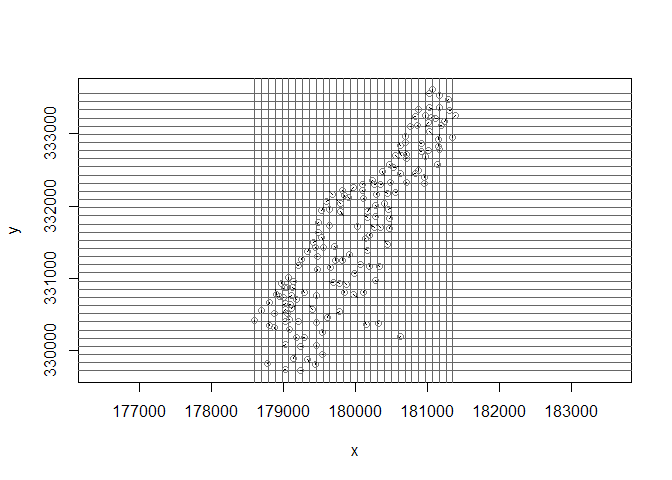

```r
# snap with no duplicates
gsnap = pkern_snap(gfull, pts=meuse.sf)
pkern_snap_plot(gsnap, meuse.sf)
```

```r
gsnap$sg$pdist |> range()
```

```
## [1]  2.858998 76.242237
```

```r
# print subgrid size
print(gsnap$sg$gdim)
```

```
##  y  x
## 35 30
```

The list (`gsnap`) returned by `pkern_snap` contains some useful indexing vectors that map input points to the full grid as well as to/from the subgrid. For example the following code shows two ways to represent the zinc data as a raster data vector containing the snapped values.

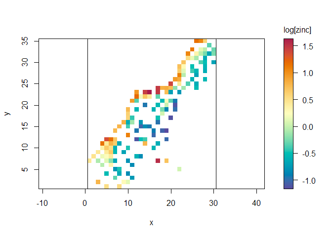

```r
# indexing vectors mapping input points to and from the subgrid
idx.to = gsnap[['sg']][['pvec']]
idx.from = gsnap[['sg']][['ipvec']]

# initialize a subgrid data vector with NAs
zinc.sg = rep(NA, prod(gsnap[['sg']][['gdim']]))

# copy zinc data at snapped grid points
zinc.sg[idx.to] = meuse$logzinc

# plot the result
pkern_plot(zinc.sg, gdim=gsnap[['sg']][['gdim']], ppars=list(leg='log[zinc]'))
```

```r
# you can also create the data vector in one line using inverse mapping
zinc.sg.compare = meuse$logzinc[idx.from]
identical(zinc.sg, zinc.sg.compare)
```

```
## [1] TRUE
```

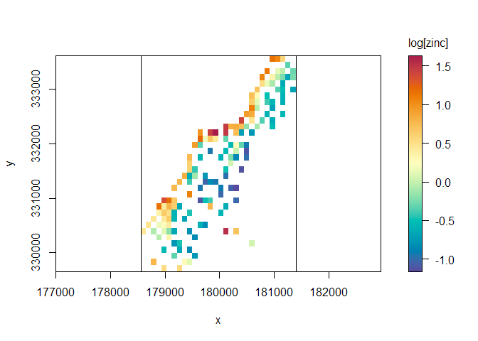

```r
# make a copy of the `gsnap$sg`, adding values field, pipe to plotter
modifyList(gsnap[['sg']], list(gval=zinc.sg)) |> pkern_plot(gtest, ppars=list(leg='log[zinc]'))
```

## Covariance model

Before we can do kriging, we need a spatial covariance model. `pkern` requires that we use a separable model (see Koch et al, 2020). In short, these models have an x component and a y component, each of which is a covariance function of distance along one dimension only.

Component covariance functions are defined by starting from the 1d correlation function (correlogram). In the example below we set up and visualize an example Gaussian correlogram using the correlation function `pkern_corr`

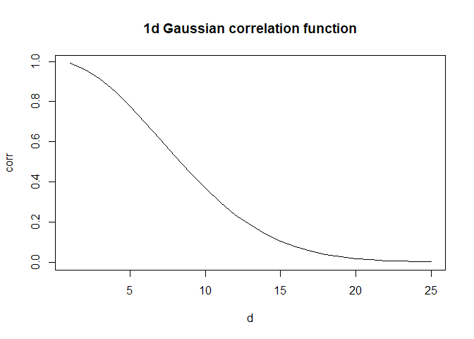

```r
# Set up a sequence of spatial lags
n = 25
d = seq(n)

# define a Gaussian correlation kernel with range 10
rho = 10
pars.1d = list(k='gau', kp=rho)

# plot correlation function
corr = pkern_corr(pars.1d, d)
plot(d, corr, pch=NA, main='1d Gaussian correlation function')
lines(d, corr)
```

```r
# correlation matrix for the lag sequence above
pkern_corrmat(pars.1d, n) |> str()
```

```
## Formal class 'dsyMatrix' [package "Matrix"] with 5 slots
##   ..@ x       : num [1:625] 1 0.99 0.961 0.914 0.852 ...
##   ..@ Dim     : int [1:2] 25 25
##   ..@ Dimnames:List of 2
##   .. ..$ : NULL
##   .. ..$ : NULL
##   ..@ uplo    : chr "U"
##   ..@ factors : list()
```

The correlation matrices returned by `pkern_corrmat` are always always (sparse) `Matrix` class, which can be helpful on bigger problems (even though here the matrix is not sparse).

A separable 2d correlogram is defined as a list with entries “y” and “x”, each a 1d kernel parameter list like `pars.1d`. These two component kernels need not have the same parameters (or be from the same function family). For example, the code below doubles the range parameter for the y component and plots the resulting 2d correlation pattern as a heatmap

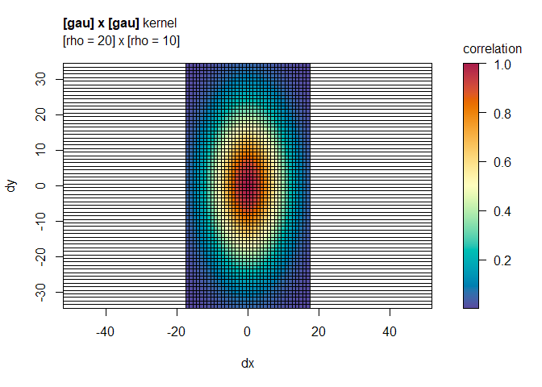

```r
# define the 1d component kernels
pars.1d.x = pars.1d
pars.1d.y = modifyList(pars.1d, list(kp=2*rho))

# define the 2d separable kernel and visualize correlation footprint
pars.2d = list(y=pars.1d.y, x=pars.1d.x)
pkern_plot(pars.2d)
```

This plot shows the correlation between a central point and all of the grid points surrounding it, illustrating the spatial pattern of correlations under the model. If you drew a transect from the middle of the heatmap to one of its edges and collected correlation values, you would get the correlogram for that direction, similar to the 1d correlation plot above.

Notice that the heatmap is not radially symmetric, which means depending on the chosen direction of your transect, the correlogram will look different. This is called “anisotropy”. All separable models are anisotropic, with the unique exception of the Gaussian with equal x and y range parameters.

To get a covariance function from a correlation function, you will need to specify the partial sill parameter (`pars$psill`), and optionally a nugget variance (`pars$nug`)

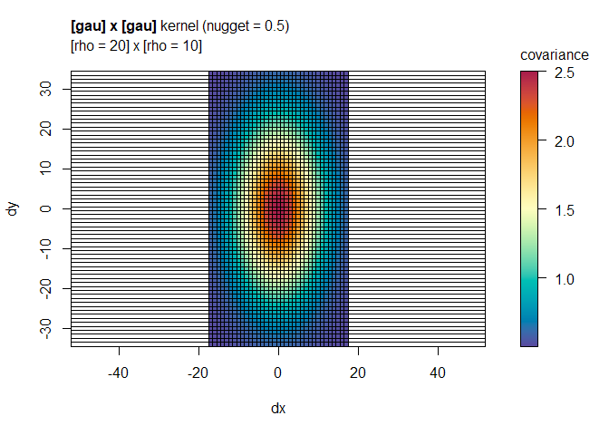

```r
# set a nugget effect and partial sill, plot semivariogram
pars.2d = modifyList(pars.2d, list(psill=2, nug=0.5))
pkern_plot(pars.2d)
```

The plot looks identical except that the color legend has a new range. The spatial pattern of the covariance function is determined by the component correlograms, whereas the nugget effect and partial sill essentially just introduce a scaling and non-zero intercept.

The simulation function `pkern_sim` is another way to visualize a covariance model. It generates random vectors from the Gaussian process which can be passed to the plotter to get a sense of what type of spatial patterns are expected under the model:

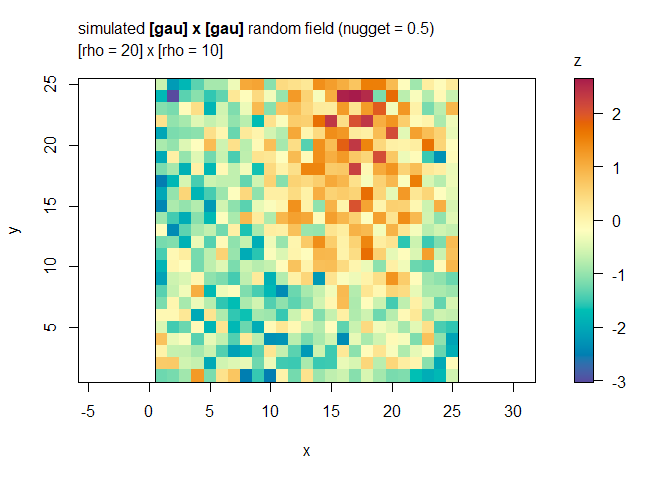

```r
# simulate data from the model defined above
pkern_sim(pars.2d)
```

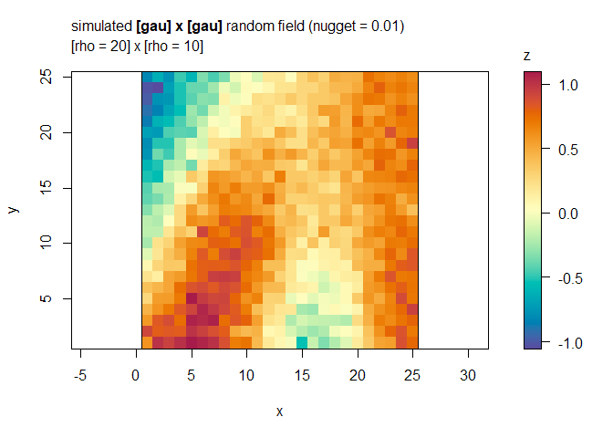

```r
# repeat with smaller nugget effect
pkern_sim(modifyList(pars.2d, list(nug=1e-2)))
```

We show next how to fit the parameters of a covariance model to a sample variogram by weighted least squares. This is not the most robust way of fitting covariance, however it is easy to understand, and fast. For users preferring likelihood based-methods, we also include the (log) likelihood function computer `pkern_LL`, which can be used in numerical optimization.

```r
# likelihood for the example model, given the meuse zinc data
pkern_LL(pars.2d, zinc.sg, gsnap[['sg']][['gdim']])
```

```
## [1] -3.194457
```

## Variograms

The function `pkern_vario` estimates sample variogram values for the the input point dataset, after snapping to the grid. It produces four sample variograms, corresponding to spatial lags along the x direction, the y direction, and the two “diagonal” directions. These four directions are selected for being computationally easy to work with when the sample data lie on a grid.

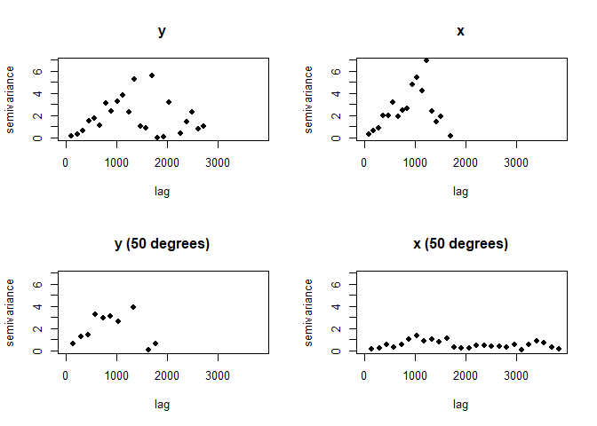

```r
# compute sample variogram
vario = pkern_vario(gdim=gsnap, vec=zinc.sg, quiet=TRUE)

# a helper function can be used to plot the results
pkern_vario_plot(vario)
```

As an aside, these sample variograms reveal some anisotropy in the random field. The diagonal x direction (corresponding to the top-right to bottom-left direction) has a much lower sill than the other directions, because we have not de-trended the data by accounting for distance to the river Meuse - this will be illustrated in another vignette

The function `pkern_vario_fit` can now be used to fit the variogram data to a model by weighted least squares. The code below does so, and plots the resulting model curves (expected variograms) over the scatterplots

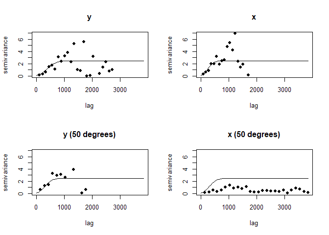

```r
# fit a separable (Gaussian) spatial covariance model to the variogram data
pars.vario = pkern_vario_fit(vario)

# plot the variograms
pkern_vario_plot(vario, pars.vario)
```

Here is what the fitted kernel looks like as a heatmap

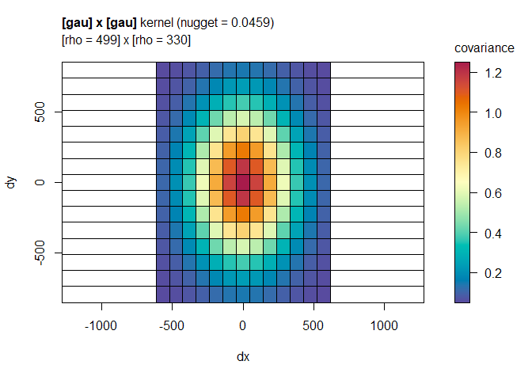

```r
# plot the fitted kernel
pkern_plot(pars.vario)
```

The fitted kernel is slightly anisotropic, with an effective range around 500m.

By default `pkern_vario_fit` uses a Gaussian covariance model, the same one used in the examples above, but any separable covariance family supported by `pkern_corr` can be specified (along with parameter bounds) in arguments `ypars` and `xpars`.

Users may also wish to set the `dmax` argument to ignore lags above a certain distance (eg. 1km looks appropriate here), or the `fit.method` argument to change the method used to weight sample variogram values. See `?pkern_vario_fit` for more details.

## Conditional expectation

The kriging function `pkern_cmean` takes the column vectorized subgrid data (in this case, `zinc.sg`), the full grid dimensions (`gdim`), and the subgrid indexing vectors (`map`), and computes the conditional mean at all grid points, given the sampled input data.

As a shortcut, users can supply the return list of `pkern_snap` to `gdim` and the function will extract `map` automatically:

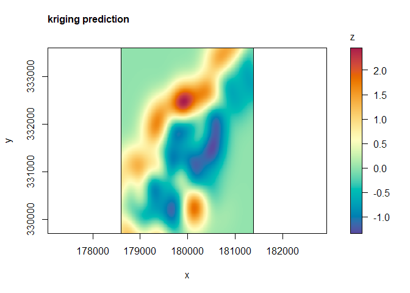

```r
# kriging to get conditional mean
zpred = pkern_cmean(zinc.sg, gsnap, pars.vario)

# plot with appropriate coordinate labels
modifyList(gsnap, list(gval=zpred)) |> pkern_plot(ppars=list(main='kriging prediction'))
```

Note that this computation happens quite fast compared to most kriging methods: The `pkern_cmean` function call takes only around 1/6 of a second to complete on my desktop for the 1 million point prediction problem.

When conditional expectation will be computed repeatedly (such as with a long time series sharing the same spatial covariance model), we can also pre-compute and recycle some of the intermediate variance components to speed things up.

## Variance components

The code below demonstrates how to copy the pre-computed model objects, `pc` for later use. On my computer, subsequent calls to `pkern_cmean` for different data vectors only take about 20 milliseconds if we pass `pc` as an argument:

```r
# pre-computed objects
pc = pkern_cmean(zinc.sg, gsnap, pars.vario, pc=TRUE)
```

The pre-computed model objects list `pc` contains grid and parameter info, along with various matrices and factorizations derived from the full covariance matrix for the outer grid, which is usually too large to work with directly.

```r
# print the names of the covariance components
names(pc)
```

```
##  [1] "gdim" "gli"  "pars" "s"    "o"    "oj"   "oi"   "sobs" "vs"   "vo"   "vso"  "vsc"  "ed"
```

```r
# they occupy very little space in memory
object.size(pc) |> print(units='Mb')
```

```
## 6 Mb
```

`pc` stores covariance and cross-covariance matrices for subsets of the grid, partitioned according to their relationship with the subgrid (“vs”, “vo”, “vso”, “vsc”). `pc` also includes indexing vectors (“s”, “o”, “oj”, “oi”, “sobs”) mapping the input point data to rows and columns of these matrices

For example, in the kriging problem one takes the covariance matrix for the input points - say `V` - and multiplies its inverse by the input data vector. Rather than storing V or its inverse, we store the diagonalization of `V` (from `base::eigen`) absent the nugget effect:

```r
# structure of the eigendecomposition for sampled data covariance V
str(pc$ed)
```

```
## List of 2
##  $ values : num [1:155] 20.5 19.1 16.9 13.7 11.7 ...
##  $ vectors: num [1:155, 1:155] -0.0571 -0.099 -0.1459 -0.1287 -0.0313 ...
##  - attr(*, "class")= chr "eigen"
```

```r
# notice there is one eigenvector per sampled point
meuse.sf |> nrow()
```

```
## [1] 155
```

V can be recovered as a submatrix of the covariance matrix for the full subgrid, which is the Kronecker product of the component y and x covariance matrices:

```r
# structure of subgrid covariance components
str(pc$vs)
```

```
## List of 2
##  $ y:Formal class 'dsyMatrix' [package "Matrix"] with 5 slots
##   .. ..@ x       : num [1:1225] 1.097 1.042 0.893 0.691 0.483 ...
##   .. ..@ Dim     : int [1:2] 35 35
##   .. ..@ Dimnames:List of 2
##   .. .. ..$ : NULL
##   .. .. ..$ : NULL
##   .. ..@ uplo    : chr "U"
##   .. ..@ factors : list()
##  $ x:Formal class 'dsyMatrix' [package "Matrix"] with 5 slots
##   .. ..@ x       : num [1:900] 1.097 1.01 0.789 0.523 0.293 ...
##   .. ..@ Dim     : int [1:2] 30 30
##   .. ..@ Dimnames:List of 2
##   .. .. ..$ : NULL
##   .. .. ..$ : NULL
##   .. ..@ uplo    : chr "U"
##   .. ..@ factors : list()
```

```r
# notice their dimensions correspond to the subgrid dimensions
gsnap$sg$gdim |> print()
```

```
##  y  x
## 35 30
```

```r
# compute the (nugget-free) sampled data covariance matrix as a submatrix of big Kronecker product
V = Matrix::kronecker(pc$vs$x, pc$vs$y)[pc$sobs, pc$sobs]

# verify the eigendecomposition works as expected
V.compare = pc$ed$vectors %*% diag(pc$ed$values) %*% t(pc$ed$vectors)
abs(V - V.compare) |> max() |> print()
```

```
## [1] 1.065814e-14
```

The variance components in `pc` are for a model without a nugget. The nugget effect is handled separately, by specifying nugget variance in element “nug” of the kernel parameters list `pars`. For example, the following code prints the nugget variance in the model fitted earlier by `pkern_vario_fit` and computes the covariance matrix for the sampled points including this nugget effect, by adding it to the diagonal matrix in the eigendecomposition.

```r
# compute V for the full model with nugget
print(pars.vario$nug)
```

```
##    fitted
## 0.0458974
```

```r
V.nugget = pc$ed$vectors %*% diag(pc$ed$values + pars.vario$nug) %*% t(pc$ed$vectors)

# notice this is quite different from the nugget-free matrix
abs(V - V.nugget ) |> max() |> print()
```

[output not shown]

The reason for handling the nugget separately like this is that our covariance components are spatially separable only when the nugget effect is zero. Separability allows the use of Kronecker products and various other computational shortcuts, so we omit the nugget effect until it is needed (eg. in `pkern_cmean`, `pkern_LL`)

For more details on the objects in `pc`, see the documentation for `pkern_precompute`